# Accelerated longitudinal and multiple group designs

Source: [`vignettes/articles/accelerated-designs.qmd`](https://github.com/cdriveraus/ctsem/blob/master/vignettes/articles/accelerated-designs.qmd)

An accelerated longitudinal design follows several cohorts, each over a short span of age, to learn about development over a longer span. The cohorts may differ, for instance because they grew up at different times or were measured with different instruments. In ctsem the cohorts are time independent predictors, which can affect any parameter, so no separate multiple group model is needed. This article fits such a design, finds which parameters differ between cohorts, and shows how to make the starting values refer to a common age.

```r
library(ctsem)
library(ggplot2)
```

## Data

Four cohorts of 50 children are each followed for two years, from ages 0, 1, 2 and 3, so that neighbouring cohorts overlap by a year. In every cohort a single process grows towards an equilibrium that differs between children. The cohorts differ in how strongly the process is pulled towards that equilibrium (the auto effect in `DRIFT`), and the older cohorts were measured with a more precise instrument. The code simulates each cohort from age 0 and keeps its two years:

```r
set.seed(1)
drift <- c(-0.3, -0.4, -0.5, -0.6)
errorsd <- c(0.6, 0.6, 0.3, 0.3)
dat <- NULL
for (cohort in 1:4) {
  gm <- ctModel(type = 'ct', silent = TRUE,
    manifestNames = 'Y', latentNames = 'eta',
    LAMBDA = 1, DRIFT = drift[cohort], DIFFUSION = 0.5,
    CINT = 'cint', T0MEANS = 0, T0VAR = 0.1,
    MANIFESTMEANS = 0, MANIFESTVAR = 0)
  d <- data.frame(ctGenerate(gm, n = 50, Tpoints = 26, dtmean = 0.2,
    backend = 'julia',
    values = list(popmeans = c(cint = 5), popsd = c(cint = 1))))
  d <- d[d$time >= cohort - 1 & d$time < cohort + 1, ]
  d$id <- paste0('cohort', cohort, '_', d$id)
  d$cohort <- cohort
  d$Yobs <- d$Y + rnorm(nrow(d), 0, errorsd[cohort])
  dat <- rbind(dat, d)
}
dat$cohort2 <- as.numeric(dat$cohort == 2)
dat$cohort3 <- as.numeric(dat$cohort == 3)
dat$cohort4 <- as.numeric(dat$cohort == 4)
head(dat)
```

```
#>          id time          Y cohort       Yobs cohort2 cohort3 cohort4
#> 1 cohort1_1  0.0 0.03981059      1 0.01814951       0       0       0
#> 2 cohort1_1  0.2 0.75362873      1 0.79632969       0       0       0
#> 3 cohort1_1  0.4 1.63277039      1 2.37289812       0       0       0
#> 4 cohort1_1  0.6 2.14152695      1 2.31299696       0       0       0
#> 5 cohort1_1  0.8 3.17685601      1 3.30633698       0       0       0
#> 6 cohort1_1  1.0 4.27070751      1 5.09589977       0       0       0
```

The true scores `Y` are kept to plot. The analysis uses `Yobs`, which has measurement error, shown faintly:

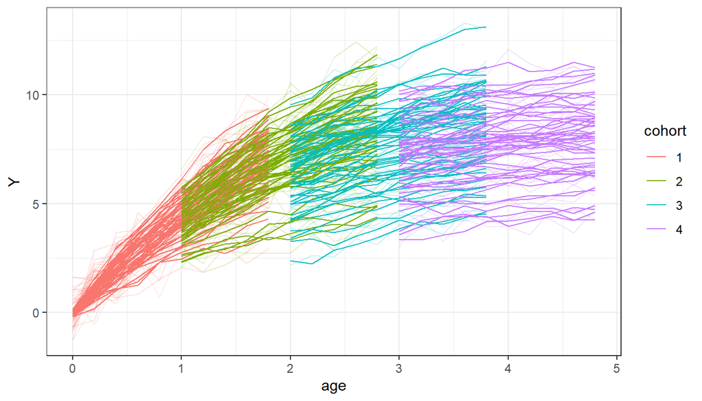

```r
ggplot(dat, aes(time, Y, colour = factor(cohort), group = id)) +
  geom_line() + geom_line(aes(y = Yobs), alpha = .2) +
  labs(x = 'age', colour = 'cohort') + theme_bw()
```

## A common starting age

The initial values of the processes, `T0MEANS`, apply at each subject’s first observation. In an accelerated design the first observation is at a different age in each cohort, so `T0MEANS` would mean a different thing for each. Giving every child a row at the earliest age in the data, with the observed variables missing but the covariates kept, makes `T0MEANS` the value at that age for everyone:

```r
start <- dat[!duplicated(dat$id), ]
start$time <- min(dat$time)
start$Y <- start$Yobs <- NA
dat <- rbind(start, dat)
dat <- dat[order(dat$id, dat$time), ]
```

## Ignoring the cohorts

The first model ignores the cohorts. The continuous time intercept `CINT` drives the growth, and by default it varies over children, as does the starting value. The measurement intercept is fixed to 0, since `T0MEANS` and `CINT` set the level.

```r
m1 <- ctModel(type = 'ct',
  manifestNames = 'Yobs', latentNames = 'eta',
  LAMBDA = 1, CINT = 'cint', MANIFESTMEANS = 0)
f1 <- ctFit(dat, m1, cores = 2)
summary(f1)$popmeans
```

```
#>             mean    sd   2.5%    50%  97.5%   mode
#> T0m_eta    0.018 0.071 -0.121  0.019  0.158  0.018
#> drift_eta -0.502 0.018 -0.536 -0.502 -0.469 -0.501
#> diff_eta   0.547 0.049  0.461  0.543  0.653  0.544
#> mvarYobs   0.492 0.013  0.467  0.492  0.517  0.491
#> cint       5.207 0.133  4.938  5.209  5.469  5.200
```

## Which parameters differ between cohorts?

`ctScoreTest()` tests, without refitting, whether a covariate would improve the model, here the cohort as a factor, and for which parameters:

```r
covariates <- unique(dat[, c('id', 'cohort')])
covariates$cohort <- factor(covariates$cohort)
ctScoreTest(f1, covariates = covariates, tests = 'covariates')
```

```
#> Score tests at the fitted model (laplace route, 200 subjects)
#>
#> Covariate cohort (factor): joint LM = 442, df = 21, p = 5e-04
#>      parameter estimate se estimate_natural      p   p_adj
#>       diff_eta       NA NA               NA <5e-04 0.00117
#>       mvarYobs       NA NA               NA <5e-04 0.00117
#>  popsd_T0m_eta       NA NA               NA <5e-04 0.00117
#>      drift_eta       NA NA               NA 0.0010 0.00175
#>        T0m_eta       NA NA               NA 0.0175 0.02450
#>     popsd_cint       NA NA               NA 0.1340 0.15600
#>           cint       NA NA               NA 0.7600 0.76000
```

The tests flag several parameters. In a model that leaves the cohorts out, one cohort difference can show up in several parameters: a cohort’s smaller measurement error, for instance, can look like smaller random change in the process (`diff_eta`). The drift and the measurement error are the differences the design suggests, so the next model adds those, and the tests are run again on it.

## Cohort effects

In the model, the cohorts are dummy variables, with the first cohort as the reference. `tipredDefault = FALSE` stops them from affecting every parameter, and the `tipreds` field of the drift and measurement error names the predictors that affect them. The cohorts shift these parameters, while the size of the individual differences stays the same in every cohort.

```r
cohorts <- 'tipreds = c(cohort2, cohort3, cohort4)'
m2 <- ctModel(type = 'ct',
  manifestNames = 'Yobs', latentNames = 'eta',
  LAMBDA = 1, CINT = 'cint', MANIFESTMEANS = 0,
  TIpredNames = c('cohort2', 'cohort3', 'cohort4'), tipredDefault = FALSE,
  DRIFT = paste('drift_eta', cohorts, sep = ', '),
  MANIFESTVAR = paste('mvar_Yobs', cohorts, sep = ', '))
f2 <- ctFit(dat, m2, cores = 2)
```

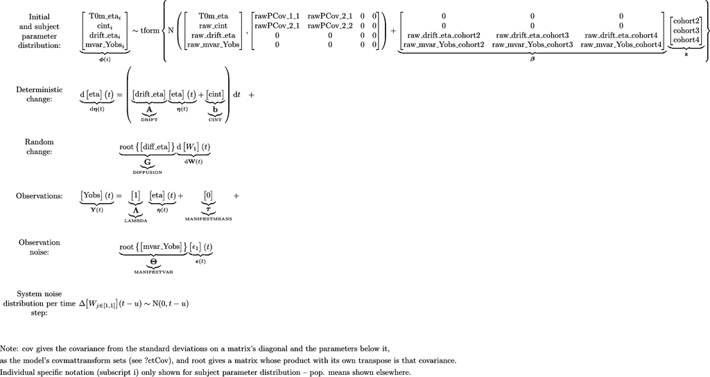

`summary()` reports the cohort effects as `tipreds`, each on the scale of the parameter it affects:

```r
summary(f2)$tipreds
```

```
#>                         mean    sd   2.5%    50%  97.5%   mode       z
#> tip_cohort2_drift_eta -0.076 0.031 -0.130 -0.079 -0.009 -0.079  -2.498
#> tip_cohort2_mvar_Yobs -0.029 0.036 -0.099 -0.029  0.039 -0.031  -0.820
#> tip_cohort3_drift_eta -0.155 0.021 -0.189 -0.157 -0.111 -0.158  -7.267
#> tip_cohort3_mvar_Yobs -0.494 0.049 -0.598 -0.494 -0.400 -0.494 -10.009
#> tip_cohort4_drift_eta -0.215 0.016 -0.241 -0.217 -0.179 -0.217 -13.422
#> tip_cohort4_mvar_Yobs -0.473 0.049 -0.566 -0.474 -0.382 -0.473  -9.633
```

Compared with the first cohort, the drift of the older cohorts is more negative, and their measurement error smaller.

```r
ctScoreTest(f2, covariates = covariates, tests = 'covariates')
```

```
#> Score tests at the fitted model (laplace route, 200 subjects)
#>
#> Covariate cohort (factor): joint LM = 14.1, df = 15, p = 0.662
#>      parameter estimate se estimate_natural     p p_adj
#>        T0m_eta       NA NA               NA 0.089 0.592
#>      drift_eta       NA NA               NA 0.242 0.592
#>  popsd_T0m_eta       NA NA               NA 0.270 0.592
#>     popsd_cint       NA NA               NA 0.438 0.592
#>      mvar_Yobs       NA NA               NA 0.501 0.592
#>       diff_eta       NA NA               NA 0.507 0.592
#>           cint       NA NA               NA 0.626 0.626
#>
#> Covariate cohort2 (in the model, on the parameters it does not act on): joint LM = 4.81, df = 3, p = 0.208
#>  parameter estimate     se estimate_natural     p p_adj
#>    T0m_eta -0.01310 0.0101          -0.1310 0.191 0.457
#>   diff_eta  0.08360 0.0805           0.0760 0.304 0.457
#>       cint -0.00154 0.0120          -0.0154 0.900 0.900
#>
#> Covariate cohort3 (in the model, on the parameters it does not act on): joint LM = 1.39, df = 3, p = 0.729
#>  parameter estimate      se estimate_natural     p p_adj
#>    T0m_eta -0.00896 0.00899         -0.08960 0.315 0.945
#>       cint -0.00599 0.01340         -0.05990 0.662 0.949
#>   diff_eta -0.00224 0.04100         -0.00203 0.949 0.949
#>
#> Covariate cohort4 (in the model, on the parameters it does not act on): joint LM = 2.98, df = 3, p = 0.392
#>  parameter estimate      se estimate_natural     p p_adj
#>    T0m_eta  0.00629 0.00455           0.0629 0.168 0.354
#>       cint  0.01110 0.01070           0.1110 0.293 0.354
#>   diff_eta -0.03900 0.04270          -0.0354 0.354 0.354
```

With the drift and measurement error effects in the model, the tests find nothing more for the cohorts to explain. The diffusion and the starting values were flagged before because the model without cohorts had no other way to show the differences in drift and measurement error.

## Cohort differences in the individual differences

A random effect has one standard deviation for everyone. To let the size of the individual differences differ between cohorts too, the stable differences can be written as a second latent process instead. That process, `intercept`, never changes (its drift and diffusion are 0) and drives `eta` with a fixed effect of 1. Its starting value differs between children through `T0VAR`, and the cohorts can then affect that variance. The random effects are turned off, since `T0VAR` now holds the individual differences.

```r
m3 <- ctModel(type = 'ct',
  manifestNames = 'Yobs', latentNames = c('eta', 'intercept'),
  LAMBDA = matrix(c(1, 0), nrow = 1),
  CINT = 0,
  DRIFT = c(
    paste('drift_eta', cohorts, sep = ', '), 1,
    0, 0),
  DIFFUSION = c(
    'diffusion_eta', 0,
    0, 0),
  T0MEANS = c('t0_eta, indvarying = FALSE',
    't0_intercept, indvarying = FALSE'),
  T0VAR = c(
    't0var_eta', 0,
    't0var_intercept_eta', paste('t0var_intercept', cohorts, sep = ', ')),
  MANIFESTMEANS = 0,
  MANIFESTVAR = paste('mvar_Yobs', cohorts, sep = ', '),
  TIpredNames = c('cohort2', 'cohort3', 'cohort4'), tipredDefault = FALSE)
f3 <- ctFit(dat, m3, cores = 2)
```

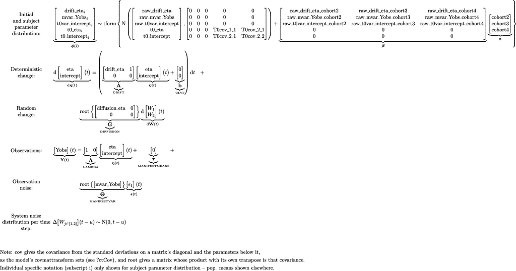

## Comparing the models

`anova()` gives the log likelihood, AIC and BIC of each fit, and likelihood ratio tests of each against the one above it:

```r
anova(f1, f2, f3)
```

```
#> Likelihood-ratio tests, each fit against the one above it
#>
#>    npar    AIC    BIC  logLik   -2LL   Chisq Df Pr(>Chisq)
#> f1    8 4197.7 4243.3 -2090.9 4181.7
#> f2   14 3809.8 3889.6 -1890.9 3781.8 399.923  6     <2e-16 ***
#> f3   17 3813.3 3910.2 -1889.7 3779.3   2.479  3     0.4791
#> ---
#> Signif. codes:  0 '***' 0.001 '**' 0.01 '*' 0.05 '.' 0.1 ' ' 1
```

The cohort effects on the drift and measurement error improve the fit a lot. The cohort effects on the size of the individual differences do not, which is how the data were generated. `ctLOO()` compares models by how well they predict data they were not fitted to, by refitting or by importance sampling.

## Predictions by cohort

`ctPredict()` with `removeObs = TRUE` gives the expected course for a child from each cohort, from the covariates alone, here over the whole age range:

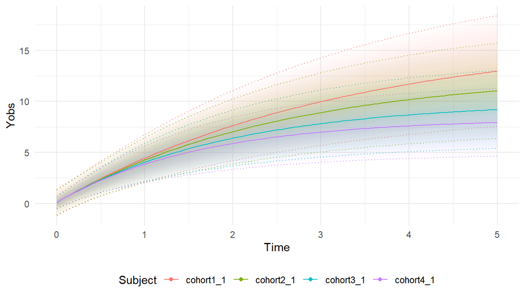

```r
firsts <- dat$id[!duplicated(dat$cohort)]
ctPredict(f2, subjects = firsts, timerange = c(0, 5), timestep = 0.05,
  removeObs = TRUE, plot = TRUE, kalmanvec = 'yprior')
```

Each cohort’s course is drawn beyond the two years it was observed in, and outside those years the curves show only what each cohort’s parameters imply. The cohort with the weakest pull towards equilibrium, the first, keeps growing the longest and settles highest.